# act_report2

## Report: act_report

- Create a **250-word-minimum written report** called "act_report.pdf" or "act_report.html" that communicates the insights and displays the visualization(s) produced from your wrangled data. This is to be framed as an external document, like a blog post or magazine article, for example.

```python
# Import functions
import os
import pandas as pd
import matplotlib.pyplot as plt
import seaborn as sns
```

```python
# Getting the data wrangling directory
data_wrangling_directory=('C:\\Users\\User\\OneDrive\\Documents\\Udacity\\Nanodegree\\Introduction_to_Data_Analysis\\data_wrangling\\')
```

## Analyzing and Visualizing Data

In this section, the cleaned and wrangled data will be analyzed and visualized, producing at least **three (3) insights and one (1) visualization.**

```python
# Reading the combined csv file using pandas read_csv function.
all_data_df_path = os.path.join(data_wrangling_directory,'combined_data\\twitter_archive_master.csv')
all_data_df= pd.read_csv(all_data_df_path)
# Viewing the first 5 rows of the all_data_df csv file containing the combined cleaned master data.
all_data_df.head(5)
```

|  | tweet_id | timestamp | source | text | expanded_urls | rating_numerator | rating_denominator | name | stage | jpg_url | ... | p1_conf | p1_dog | p2 | p2_conf | p2_dog | p3 | p3_conf | p3_dog | retweet_count | favorite_count |
| --- | --- | --- | --- | --- | --- | --- | --- | --- | --- | --- | --- | --- | --- | --- | --- | --- | --- | --- | --- | --- | --- |
| 0 | 890240255349198849 | 2017-07-26 15:59:51 | <a href="http://twitter.com/download/iphone" rel="nofollow">Twitter for iPhone</a> | This is Cassie. She is a college pup. Studying international doggo communication and stick theory. 14/10 so elegant much sophisticate https://t.co/t1bfwz5S2A | https://twitter.com/dog_rates/status/890240255349198849/photo/1 | 14 | 10 | Cassie | doggo | https://pbs.twimg.com/media/DFrEyVuW0AAO3t9.jpg | ... | 0.511319 | True | Cardigan | 0.451038 | True | Chihuahua | 0.029248 | True | 5958 | 27070 |
| 1 | 889531135344209921 | 2017-07-24 17:02:04 | <a href="http://twitter.com/download/iphone" rel="nofollow">Twitter for iPhone</a> | This is Stuart. He's sporting his favorite fanny pack. Secretly filled with bones only. 13/10 puppared puppo #BarkWeek https://t.co/y70o6h3isq | https://twitter.com/dog_rates/status/889531135344209921/photo/1 | 13 | 10 | Stuart | puppo | https://pbs.twimg.com/media/DFg_2PVW0AEHN3p.jpg | ... | 0.953442 | True | Labrador_retriever | 0.013834 | True | redbone | 0.007958 | True | 1847 | 12937 |
| 2 | 886366144734445568 | 2017-07-15 23:25:31 | <a href="http://twitter.com/download/iphone" rel="nofollow">Twitter for iPhone</a> | This is Roscoe. Another pupper fallen victim to spontaneous tongue ejections. Get the BlepiPen immediate. 12/10 deep breaths Roscoe https://t.co/RGE08MIJox | https://twitter.com/dog_rates/status/886366144734445568/photo/1 | 12 | 10 | Roscoe | pupper | https://pbs.twimg.com/media/DE0BTnQUwAApKEH.jpg | ... | 0.999201 | True | Chihuahua | 0.000361 | True | Boston_bull | 0.000076 | True | 2561 | 17974 |
| 3 | 884162670584377345 | 2017-07-09 21:29:42 | <a href="http://twitter.com/download/iphone" rel="nofollow">Twitter for iPhone</a> | Meet Yogi. He doesn't have any important dog meetings today he just enjoys looking his best at all times. 12/10 for dangerously dapper doggo https://t.co/YSI00BzTBZ | https://twitter.com/dog_rates/status/884162670584377345/photo/1 | 12 | 10 | Yogi | doggo | https://pbs.twimg.com/media/DEUtQbzW0AUTv_o.jpg | ... | 0.707046 | True | malinois | 0.199396 | True | Norwegian_elkhound | 0.049148 | True | 2441 | 17366 |
| 4 | 883360690899218434 | 2017-07-07 16:22:55 | <a href="http://twitter.com/download/iphone" rel="nofollow">Twitter for iPhone</a> | Meet Grizzwald. He may be the floofiest floofer I ever did see. Lost eyes saving a schoolbus from a volcano erpuption. 13/10 heroic as h*ck https://t.co/rf661IFEYP | https://twitter.com/dog_rates/status/883360690899218434/photo/1 | 13 | 10 | Grizzwald | floofer | https://pbs.twimg.com/media/DEJT3FeXoAAtwUy.jpg | ... | 0.987997 | True | Tibetan_mastiff | 0.007099 | True | Newfoundland | 0.002140 | True | 3005 | 19304 |

5 rows × 22 columns

### Insights:

1. **What are the top 25 common predictions the model/algorithm makes?**: The most common and top three(3) predictions made by the model/algorithm are 'golden_retriever', 'Pomeranian', and 'Labrador_retriever'. Others includes the; 'Pembroke', 'German_shepherd', 'pug', 'Border_collie', 'porcupine', 'Eskimo_dog', 'Chihuahua', 'boxer', 'miniature_pinscher', 'French_bulldog', 'chow', 'Siberian_husky', 'Lakeland_terrier', 'toy_poodle', 'cocker_spaniel', 'American_Staffordshire_terrier', 'whippet', 'Old_English_sheepdog', 'bloodhound', 'Cardigan', 'dalmatian', and 'Bernese_mountain_dog'.
1. **What are the top 10 model predictions correctly predictly as a dog with an average confidence score greater than 80%?**: The top 3 dog model predictions with an average confidence score greater than 80% are 'Bernese_mountain_dog', 'komondor', and 'Samoyed'. Others are; 'Bernese_mountain_dog', 'komondor', 'Samoyed', 'clumber', 'German_short-haired_pointer','dalmatian', 'French_bulldog', 'American_Staffordshire_terrier', 'pug', and 'Labrador_retriever' respectively.
1. **What is the favorite count for each dog stage?**: Doggos have a higher favorite count (approx. 15,601) and retweet_count (approx. 4,454) on average when compared to other dog stages. Next is the puppo, fluffer, and pupper with an approximate favorite count of 10352, 7939, and 6307 likes respectively. Therefore, doggos are popularly admired more when compared to the other dog stages and this could be associated with the fact that they are older and often more composed/well-behaved.

### Visualization

###### Displaying the histogram of the cleaned and combined data.

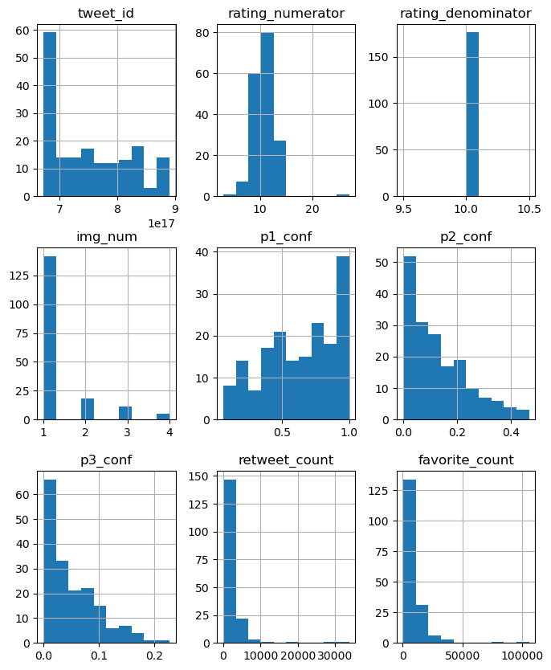

```python
# Plotting the histogram of the cleaned and combined data.
all_data_df.hist(figsize=(8,10));
```

###### Note:

```python
# Plot functions used for visualization.

def plot_size_and_weight(plot_graph, bold_font=False):
    # To update/change the fontsize of the plot.
    for plot_label in (plot_graph.get_xticklabels() + plot_graph.get_yticklabels()):
        plot_label.set_fontsize(20)
        if bold_font==True:
            plot_label.set_fontweight('bold')

def axis_and_titles(plot_title, xaxis_label, yaxis_label, set_grid=False):
    # Setting the title of the figure.
    plt.title(str(plot_title),fontsize = 20)
    # Setting the x-label and y-label of the plot.
    plt.xlabel(str(xaxis_label),fontsize = 18)
    plt.ylabel(str(yaxis_label),fontsize = 18)
    if set_grid==True:
        sns.set_style("whitegrid")
```

**What are the top 25 common predictions the model/algorithm makes?**

```python
# To display the value count of the models predictions.
all_data_df.p1.value_counts().sort_values(ascending=False).iloc[:25]
```

```
golden_retriever                  14
Pomeranian                        6
Labrador_retriever                6
Pembroke                          6
German_shepherd                   5
pug                               5
Border_collie                     4
porcupine                         4
Eskimo_dog                        4
Chihuahua                         4
boxer                             3
miniature_pinscher                3
French_bulldog                    3
chow                              3
Siberian_husky                    3
Lakeland_terrier                  3
toy_poodle                        3
cocker_spaniel                    3
American_Staffordshire_terrier    2
whippet                           2
Old_English_sheepdog              2
bloodhound                        2
Cardigan                          2
dalmatian                         2
Bernese_mountain_dog              2
Name: p1, dtype: int64
```

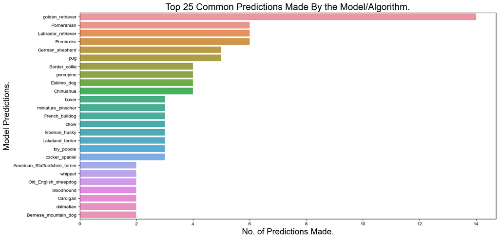

```python
# Plot of the Top 25 Common Predictions Made By the Model/Algorithm.
fig, ax = plt.subplots(figsize=(16, 8))
x_axis= all_data_df.p1.value_counts().sort_values(ascending=False).iloc[:25]
y_axis=x_axis.index
sns.barplot(x=x_axis, y=y_axis, orient='h')
axis_and_titles(plot_title='Top 25 Common Predictions Made By the Model/Algorithm.',
                xaxis_label= 'No. of Predictions Made.',
                yaxis_label= 'Model Predictions.',
                set_grid=True)
```

**What are the top 10 model predictions correctly predictly as a dog with an average confidence score greater than 80%**

```python
# Getting all model predictions sorted based on the confidence score and if it is a dog or not.
all_data_df.groupby('p1')['p1_conf','p1_dog'].mean().sort_values(by=['p1_dog', 'p1_conf'], ascending=False)
```

| p1 | p1_conf | p1_dog |
| --- | --- | --- |
| Bernese_mountain_dog | 0.977165 | 1.0 |
| komondor | 0.974781 | 1.0 |
| Samoyed | 0.950053 | 1.0 |
| clumber | 0.946718 | 1.0 |
| German_short-haired_pointer | 0.935771 | 1.0 |
| ... | ... | ... |
| space_heater | 0.206876 | 0.0 |
| jack-o'-lantern | 0.172079 | 0.0 |
| bow | 0.168020 | 0.0 |
| wooden_spoon | 0.082489 | 0.0 |
| home_theater | 0.059033 | 0.0 |

100 rows × 2 columns

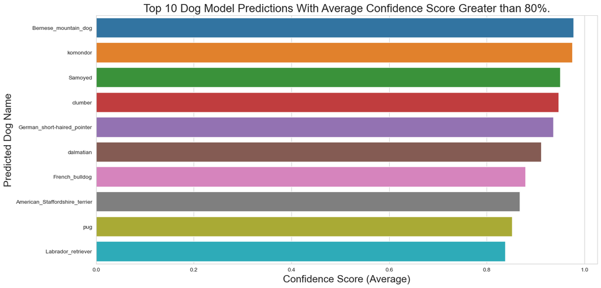

```python
# Plot of the Top 10 Dog Model Predictions With Average Confidence Score Greater than 80%.
fig, ax = plt.subplots(figsize=(16, 8))
x_axis=all_data_df.groupby('p1')['p1_conf','p1_dog'].mean().sort_values(by=['p1_dog', 'p1_conf'], ascending=False).p1_conf.iloc[:10]
y_axis=x_axis.index
sns.barplot(x=x_axis, y=y_axis, orient='h')
axis_and_titles(plot_title='Top 10 Dog Model Predictions With Average Confidence Score Greater than 80%.',
                xaxis_label='Confidence Score (Average)',
                yaxis_label='Predicted Dog Name',
                set_grid=True)
```

In this case, the model/algorithm is able to predict with over 80% confidence on an average that the prediction made is a 'dog'. For example, the model was able to properly learn and identify the distinct features of the 'Bernese Mountain dog' with a 97.7% confidence score. This is same with the other 9 predictions where the model could predict them with a confidence score greater than 80%. In addition, though the 'Bernese Mountain dog' was not commonly predicted as often by the model, the model could the distinguish its features with a high confidence score.

**What is the favorite count for each dog stage?**

```python
# Grouping the dog stages by the average of the retweet count.
all_data_df.groupby('stage')['retweet_count'].mean().sort_values(ascending=False)
```

```
stage
doggo      4454.171429
puppo      2598.866667
floofer    1775.600000
pupper     1772.966942
Name: retweet_count, dtype: float64
```

```python
# Grouping the dog stages by the average of the favorite count.
all_data_df.groupby('stage')['favorite_count'].mean().sort_values(ascending=False)
```

```
stage
doggo      15601.857143
puppo      10352.600000
floofer    7939.400000
pupper     6307.132231
Name: favorite_count, dtype: float64
```

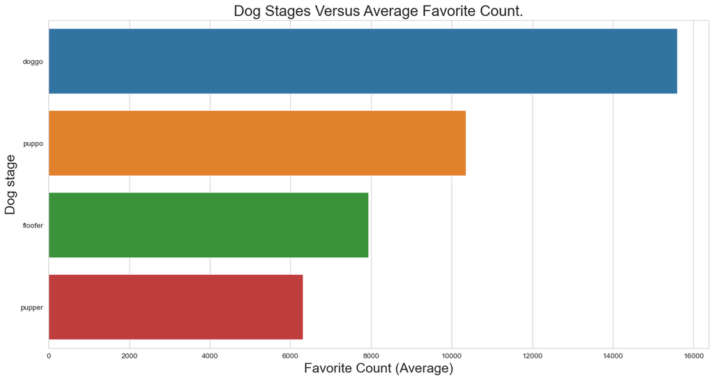

```python
# Plot of the Dog Stages Versus the Average Favorite Count.
fig, ax = plt.subplots(figsize=(16, 8))
x_axis= all_data_df.groupby('stage')['favorite_count'].mean().sort_values(ascending=False).iloc[:]
y_axis=x_axis.index
sns.barplot(x=x_axis, y=y_axis, orient='h')
axis_and_titles(plot_title='Dog Stages Versus Average Favorite Count.',
                xaxis_label='Favorite Count (Average)',
                yaxis_label='Dog stage',
                set_grid=True)
```

From the plot above, 'doggo' has displayed the highest favorite count with approximately 15,601 likes on average when combined. From analysis, images of doggos are also among the most retweeted images with a high retweet count of approximately 4,454 when combined on an average. Hence, doggos tend to be more popularly admired when compared to other dog stages and this could be attributed to the fact that they are older and often more composed/well-behaved.